# UTAS report

### Maneuver difficulty

Table 1. Percent failure per maneuver

| SubManeuver | perc.fail | Difficulty |
| --- | --- | --- |
| Circle to Land | 33.33 | C |
| Steep Turns | 25.81 | C |
| TCAS | 17.78 | C |
| Departure Stall | 16.67 | NA |
| MissedApproach | 14.44 | NA |
| RTO | 13.19 | C |
| Upset Recovery | 8.79 | C |
| Holding | 7.78 | B |
| Area Departure | 6.67 | C |
| Takeoff | 5.56 | C |
| No Slat/Flap Malfunction | 3.33 | NA |
| Abnormal/Emergency Procedure | 0.00 | NA |
| Area Arrival | 0.00 | NA |
| Approach | NA | C |
| Landing | NA | C |
| Waypoint | NA | C |

### Analysis of Simulator Data per Maneuver

Objective: Find flight metrics that discriminate pilots’ flight performance and associate to cockpit conditions and physiological responses.

### TCAS

#### Absolute delta calspeed=|CalibratedAirspeed (t) - CalibratedAirspeed (t=0)|

### Departure stall

Metric of interest: Speed recovery time

Description: time elapsed from minimum speed point to regaining 75% of the initial air speed

Relation to Instructor Ratings:

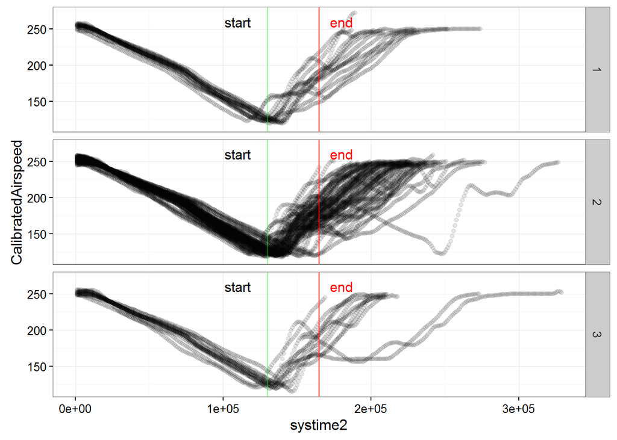

### Upset Recovery

Metric: Altitude recovery after upset

Description: Approximately 50 seconds after the beginning of the maneuver, altitude values seem to stabilize near the initial altitude (~5000m?) .

Deviations from this target altitude are the largest in the medium and high co2 conditions

Relation to CO2 Conditions:

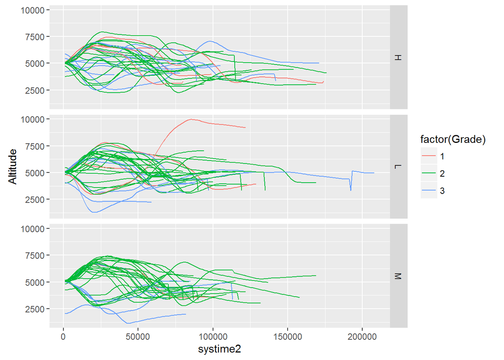

| Condition | Mean_altitude |
| --- | --- |
| H | 4632.539 |
| L | 5023.907 |
| M | 4530.273 |

Metric: Bank Angle variability

Description: bank angle values oscillate closer to zero degrees 50 seconds after the beginning of the maneuver.

### Circle to Land

Metric: Maintain altitude during circle to land

Description: Absolute deviation from 700 ft during circle to land

Relation to Instructor Ratings:

| Grade | Mean_Deviation |
| --- | --- |
| 1 | 25.22470 |
| 2 | 22.74981 |
| 3 | 23.83954 |

Relation to CO2 Conditions:

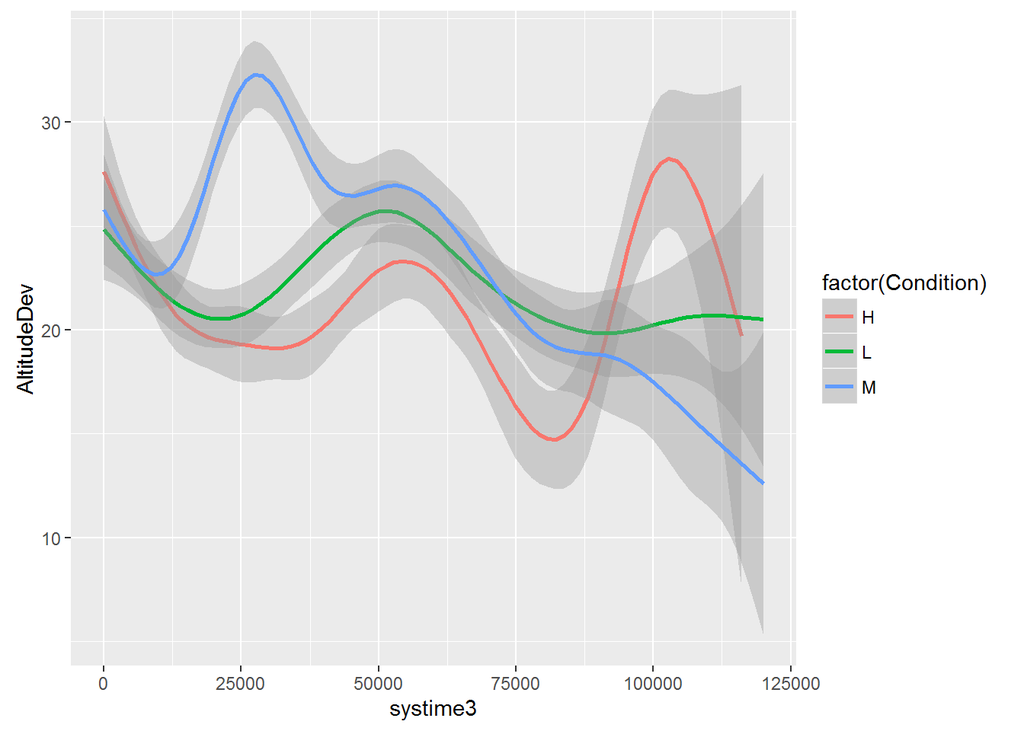

### Takeoff

Metric: Bank angle during takeoff

Description: Absolute deviation from 0 during takoff, up to 400 ft

Relation to Instructor Ratings:

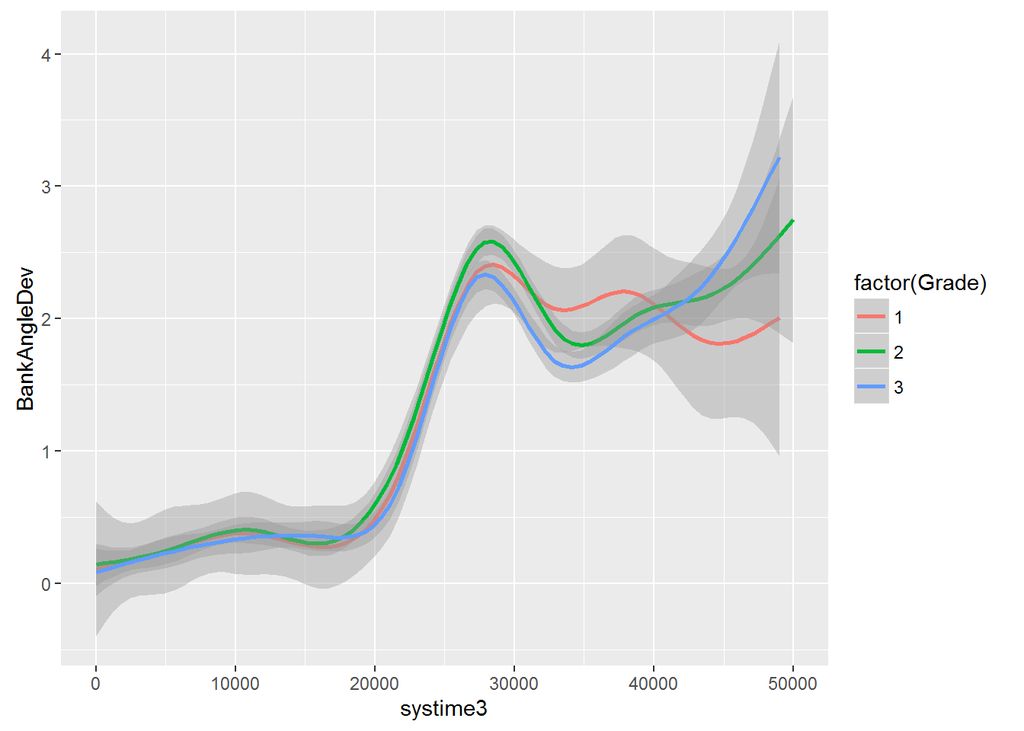

Relation to CO2 Conditions:

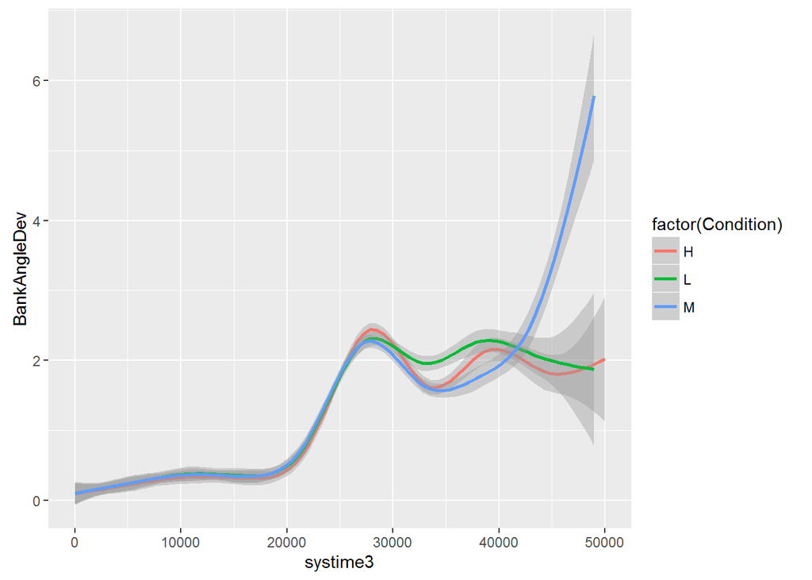

### Area Departure with Engine Fire

Metric: Constant Rate of Ascent from 400ft to 1500ft

Description: Absolute deviation from pitch attitude of 15

Relation to Instructor Ratings:

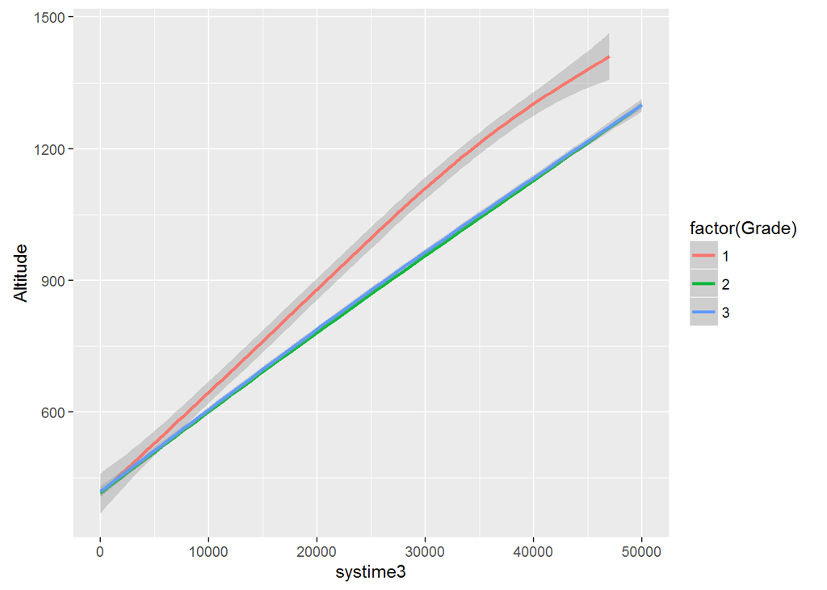

| Grade | Mean_Deviation |
| --- | --- |
| 1 | 0.8693538 |
| 2 | 0.8921100 |
| 3 | 0.8314425 |

Relation to CO2 Conditions:

| Condition | Mean_Deviation |
| --- | --- |
| H | 0.9400966 |
| L | 0.7680649 |
| M | 0.9194132 |

### Steep Turns

Metric: Bank Angle of 45 Degrees

Description: Deviation from 45 degrees while in steep turns

Relation to Instructor Ratings:

| Grade | Mean_Deviation |
| --- | --- |
| 1 | 59.94475 |
| 2 | 54.90310 |
| 3 | 52.25905 |

Relation to CO2 Conditions:

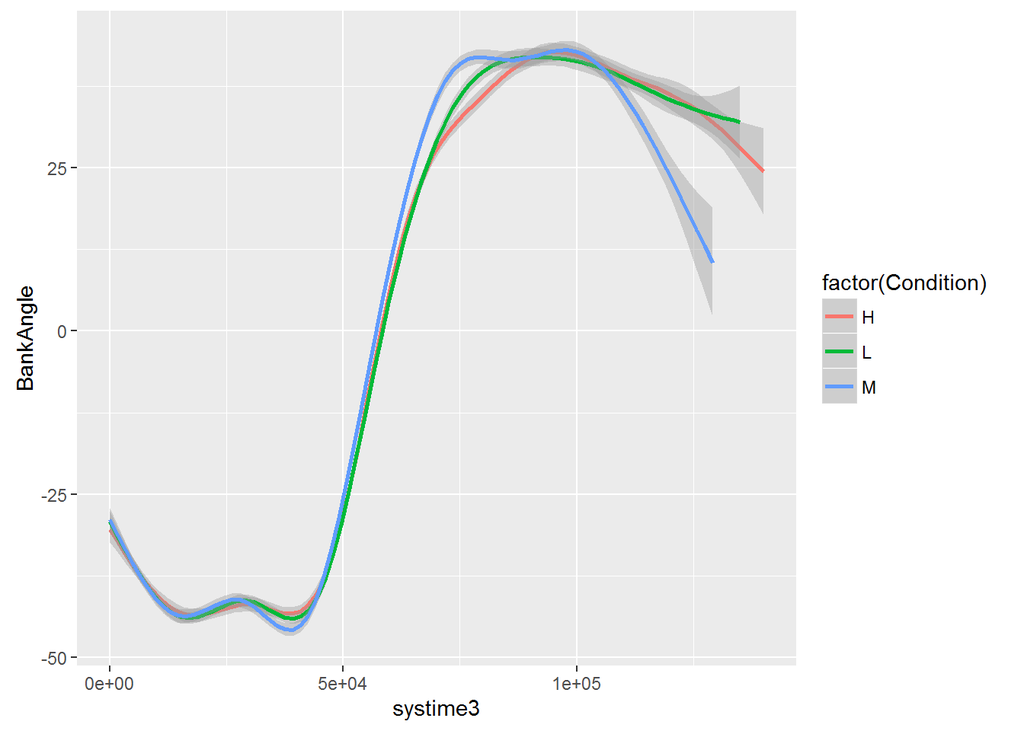

| Condition | Mean_Deviation |
| --- | --- |
| H | 54.05053 |
| L | 58.32615 |
| M | 54.42605 |

### Landing

Metric: Bank angle during final approach and landing

Description: Absolute deviation from 0 during landing

Relation to Instructor Ratings:

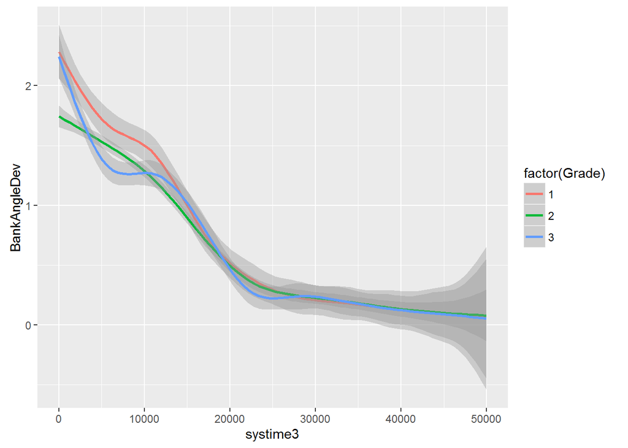

Relation to CO2 Conditions:

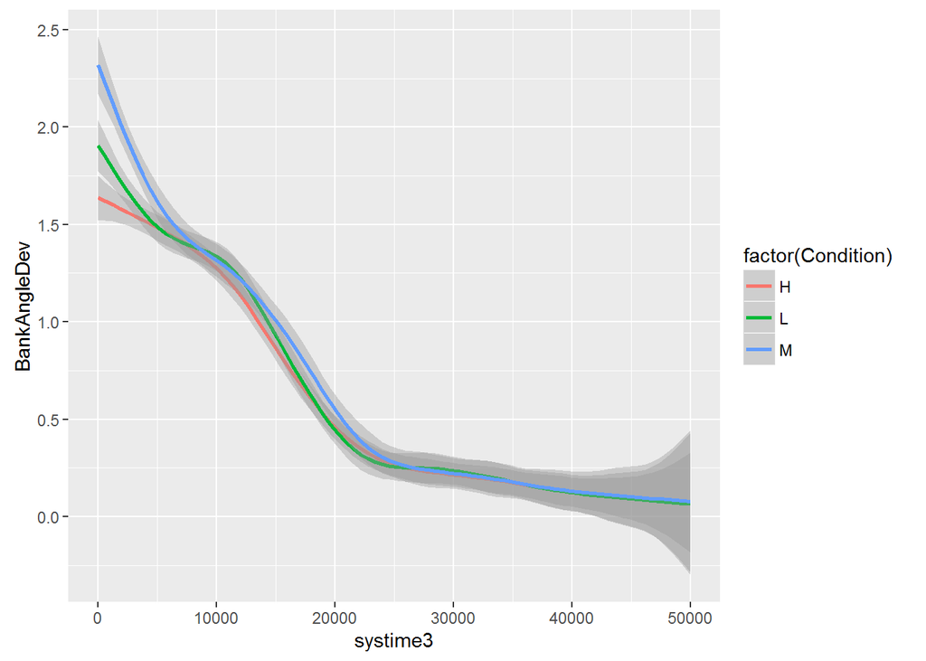